# Reproducible Research: Peer Assessment 1

### 1. Loading and preprocessing the data

Show any code that is needed to :

- 1. Load the data

```r
activity <- read.csv(file='./activity.csv', stringsAsFactors = FALSE)
str(activity)
```

```
## 'data.frame':    17568 obs. of  3 variables:
##  $ steps   : int  NA NA NA NA NA NA NA NA NA NA ...
##  $ date    : chr  "2012-10-01" "2012-10-01" "2012-10-01" "2012-10-01" ...
##  $ interval: int  0 5 10 15 20 25 30 35 40 45 ...
```

- 2. Process/transform the data(if necessary) into a format suitable for your analysis

```r
activity$date <-  as.Date(activity$date, "%Y-%m-%d")
str(activity)
```

```
## 'data.frame':    17568 obs. of  3 variables:
##  $ steps   : int  NA NA NA NA NA NA NA NA NA NA ...
##  $ date    : Date, format: "2012-10-01" "2012-10-01" ...
##  $ interval: int  0 5 10 15 20 25 30 35 40 45 ...
```

### 2. What is mean total number of steps taken per day?

- 1. Calculate the total number of steps taken per day

```r
stepsperday = aggregate(activity$steps, by=list(Dates=activity$date), FUN=sum)
colnames(stepsperday) <- c('Date','StepsPerDay')
stepsperday
```

```
##          Date StepsPerDay
## 1  2012-10-01          NA
## 2  2012-10-02         126
## 3  2012-10-03       11352
## 4  2012-10-04       12116
## 5  2012-10-05       13294
## 6  2012-10-06       15420
## 7  2012-10-07       11015
## 8  2012-10-08          NA
## 9  2012-10-09       12811
## 10 2012-10-10        9900
## 11 2012-10-11       10304
## 12 2012-10-12       17382
## 13 2012-10-13       12426
## 14 2012-10-14       15098
```

[output cut: 47 more lines]

- 2. Make a histogram of the total number of steps taken each day

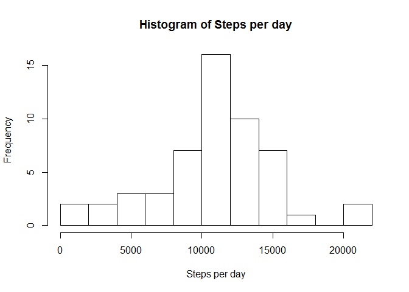

```r
hist(stepsperday$StepsPerDay, breaks = 10, xlab = 'Steps per day',
     main = paste("Histogram of Steps per day"))
```

```r
meanSteps = mean(stepsperday$StepsPerDay, na.rm = TRUE)
medSteps = median(stepsperday$StepsPerDay, na.rm = TRUE)
```

### 3. What is the average daily activity pattern?

- 1. Make a time series plot (i.e. type = “l”) of the 5-minute interval (x-axis) and the average number of steps taken, averaged across all days (y-axis)

```r
dailyActivity = aggregate(activity$steps, by=list(intervals=activity$interval), FUN=mean, na.rm = TRUE)
colnames(dailyActivity) <- c('Interval','Steps')
head(dailyActivity)
```

```
##   Interval     Steps
## 1        0 1.7169811
## 2        5 0.3396226
## 3       10 0.1320755
## 4       15 0.1509434
## 5       20 0.0754717
## 6       25 2.0943396
```

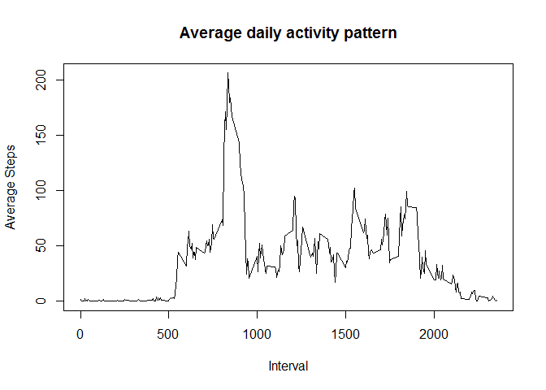

```r
plot(dailyActivity$Interval, dailyActivity$Steps, type="l",
     xlab = 'Interval', ylab = 'Average Steps', main = 'Average daily activity pattern')
```

- 2. Which 5-minute interval, on average across all the days in the dataset, contains the maximum number of steps?

```r
dailyActivity[ dailyActivity$Steps == max(dailyActivity$Steps), ]
```

```
##     Interval    Steps
## 104      835 206.1698
```

### Imputing missing values

Note that there are a number of days/intervals where there are missing values (coded as NA). The presence of missing days may introduce bias into some calculations or summaries of the data.

- 1. Calculate and report the total number of missing values in the dataset (i.e. the total number of rows with NAs)

```r
na_count = sum(is.na(activity$steps))
na_count
```

```
## [1] 2304
```

- 2. Devise a strategy for filling in all of the missing values in the dataset. The strategy does not need to be sophisticated. For example, you could use the mean/median for that day, or the mean for that 5-minute interval, etc.

- 3. Create a new dataset that is equal to the original dataset but with the missing data filled in.

```r
na_index = is.na(activity$steps)
na_intervals = activity$interval[na_index]
replace_vals = dailyActivity$Steps[dailyActivity$Interval == na_intervals]
newactivity = activity
newactivity$steps[na_index] = replace_vals
head(newactivity)
```

```
##       steps       date interval
## 1 1.7169811 2012-10-01        0
## 2 0.3396226 2012-10-01        5
## 3 0.1320755 2012-10-01       10
## 4 0.1509434 2012-10-01       15
## 5 0.0754717 2012-10-01       20
## 6 2.0943396 2012-10-01       25
```

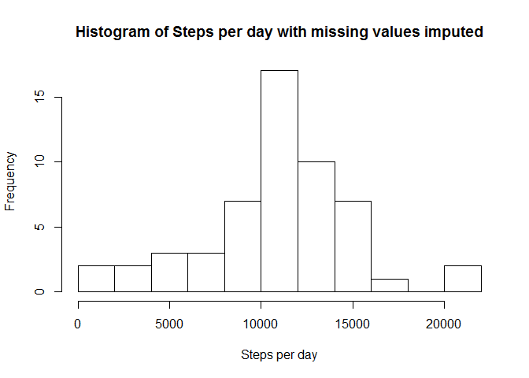

```r
newstepsperday = aggregate(newactivity$steps, by=list(Dates=newactivity$date), FUN=sum)
colnames(newstepsperday) <- c('Date','StepsPerDay')

# Make histogram
hist(newstepsperday$StepsPerDay, breaks = 10, , xlab = 'Steps per day',
     main = paste("Histogram of Steps per day with missing values imputed"))
```

```r
newmeanSteps = mean(newstepsperday$StepsPerDay, na.rm = TRUE)
newmedSteps = median(newstepsperday$StepsPerDay, na.rm = TRUE)
```

### Are there differences in activity patterns between weekdays and weekends?

For this part the weekdays() function may be of some help here. Use the dataset with the filled-in missing values for this part.

- 1. Create a new factor variable in the dataset with two levels - “weekday” and “weekend” indicating whether a given date is a weekday or weekend day.

We use the chron library to determine if the date is weekend or not

```r
library(chron)
isWeekend = is.weekend(newactivity$date)
newactivity$dateType = factor(isWeekend, labels = c("weekday", "weekend"))
head(newactivity)
```

```
##       steps       date interval dateType
## 1 1.7169811 2012-10-01        0  weekday
## 2 0.3396226 2012-10-01        5  weekday
## 3 0.1320755 2012-10-01       10  weekday
## 4 0.1509434 2012-10-01       15  weekday
## 5 0.0754717 2012-10-01       20  weekday
## 6 2.0943396 2012-10-01       25  weekday
```

- 2. Make a panel plot containing a time series plot (i.e. type = “l”) of the 5-minute interval (x-axis) and the average number of steps taken, averaged across all weekday days or weekend days (y-axis). See the README file in the GitHub repository to see an example of what this plot should look like using simulated data.

```r
weekdayactivity = newactivity[newactivity$dateType == "weekday",]
weekendactivity = newactivity[newactivity$dateType == "weekend",]

# Compute the values for weekdays
dailyweekdayactivity = aggregate(weekdayactivity$steps, by=list(intervals=weekdayactivity$interval), FUN=mean, na.rm = TRUE)
colnames(dailyweekdayactivity) <- c('Interval','Steps')
dailyweekdayactivity$dateType = factor(rep(0,length(dailyweekdayactivity$Steps)), labels = "weekday")
head(dailyweekdayactivity)
```

```
##   Interval     Steps dateType
## 1        0 2.3179245  weekday
## 2        5 0.4584906  weekday
## 3       10 0.1783019  weekday
## 4       15 0.2037736  weekday
## 5       20 0.1018868  weekday
## 6       25 1.5273585  weekday
```

```r
# Compute the values for weekends
dailyweekendactivity = aggregate(weekendactivity$steps, by=list(intervals=weekendactivity$interval), FUN=mean, na.rm = TRUE)
colnames(dailyweekendactivity) <- c('Interval','Steps')
dailyweekendactivity$dateType = factor(rep(0,length(dailyweekendactivity$Steps)), labels = "weekend")
head(dailyweekendactivity)
```

```
##   Interval    Steps dateType
## 1        0 0.000000  weekend
## 2        5 0.000000  weekend
## 3       10 0.000000  weekend
## 4       15 0.000000  weekend
## 5       20 0.000000  weekend
## 6       25 3.714286  weekend
```

```r
# Combine the result
newdailyactivity = rbind(dailyweekdayactivity,dailyweekendactivity)
str(newdailyactivity)
```

```
## 'data.frame':    576 obs. of  3 variables:
##  $ Interval: int  0 5 10 15 20 25 30 35 40 45 ...
##  $ Steps   : num  2.318 0.458 0.178 0.204 0.102 ...
##  $ dateType: Factor w/ 2 levels "weekday","weekend": 1 1 1 1 1 1 1 1 1 1 ...
```

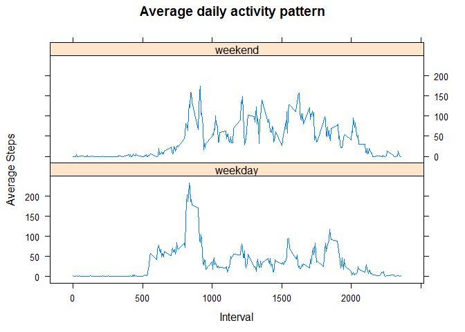

```r
# Plot the result
library(lattice)
xyplot(Steps~Interval | factor(dateType), data=newdailyactivity,
                main="Average daily activity pattern", xlab="Interval",  ylab="Average Steps",layout=c(1,2),type='l')
```